# Lab 02: Tidy Data

Zakary Draper

Sep 17, 2020

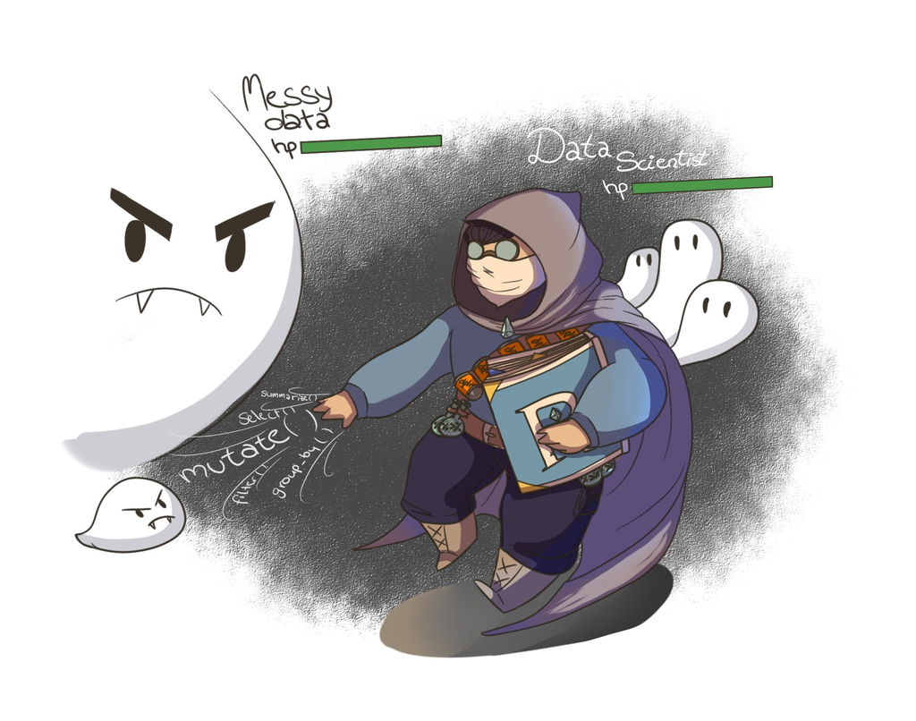

Source: [@ViviFabrien](https://twitter.com/ViviFabrien/status/1251482525706457088/photo/1)

## Prepare for the Lab

We will be covering data import in the lab, which is discussed in [R4DS, 11 Data import](https://r4ds.had.co.nz/data-import.html). The R4DS chapter goes into more detail than we will be learning for the lab. So, only read it if you’re interested. Be aware that it is a good reference for when you have questions about data import in the future.

## Lab Activity

Create a new RStudio project called “02-tidy-data”. In the project folder create folders “data” and “src”.[^1]

Today’s activity involves importing 3 non-tidy data sets into R and wrangling them into tidy tibbles. Complete the following steps for each of the three data sets.

1. Import the file into R and save at as an object with a short, descriptive name.
2. Inspect the object by printing it to the console, and with `View()` and `glimpse()`.
3. Use `tidyr` functions to tidy the data.

Descriptions of the (imaginary) studies and codebooks for each data set are provided below.

### Study 1: Does resilience increase voluntary exposure to pain?

#### Description

These data come from a study designed to examine the relationship between resilience and willingness to be exposed to pain. Participants responded to the [Brief Resilience Scale (BRS)](https://ogg.osu.edu/media/documents/MB%20Stream/Brief%20Resilience%20Scale.pdf). They were then instructed to submerge their hand in a bucket of ice water while counting either 20, 40, or 60 seconds in their head. They were told to remove their hand as close to the specified time as they could (or as long as they could). A research assistant measured duration time and instructed participants to remove their hand if more than 90 seconds had passed.

#### Codebook

| variable | description |
| --- | --- |
| pid | randomly generated unique identifier of each participant |
| age_and_sex | participants self-reported age and sex |
| brs_mean | participants mean score on the Brief Resilience Scale (BRS) |
| tc1 | 20 second condition; time with hand in ice bath |
| tc2 | 40 second condition; time with hand in ice bath |
| tc3 | 60 second condition; time with hand in ice bath |

### Study 2: How does life satisfaction change in the first months of marriage?

#### Description of Data

This data set comes from a study investigating changes in life satisfaction following marriage. Life satisfaction was measured using the [Satisfaction with Life Scale (SWLS)](https://fetzer.org/sites/default/files/images/stories/pdf/selfmeasures/SATISFACTION-SatisfactionWithLife.pdf) on the day a participant was married and then again every 30 days for the first 120 days after that.

#### Codebook

| var | desc |
| --- | --- |
| participant_id | unique participant ID |
| age | age in years when participant was married |
| swls_t1 | Satisfaction with Life Scale (SWLS) total on day of marriage |
| swls_t2 | SWLS total after 30 days of marriage |
| swls_t3 | SWLS total after 60 days of marriage |
| swls_t4 | SWLS total after 90 days of marriage |
| swls_t5 | SWLS total after 120 days of marriage |

### Study 3: Reward expectations and stress

#### Codebook

| variable | description |
| --- | --- |
| rid | Participant research ID |
| reward | Size of reward: no reward = $0; small reward = $1; large reward = $10 |
| time | Measurement time: t1 = baseline; t2 = after notification of condition; t3 = after receiving reward |
| stress | Self-report stress (scale of 1 to 5) |

[^1]: “src” is short for “source code”. It’s a reminder to think of your code as the “source” of the objects you create in R.